# Extract roads

2023-05-24

## Introduction

What we care most from the Agoop data is the time lag between every two cars in our real world. However, the problem is that to calculate the time lag, we need at least two cars (obviously), while the maximum number of cars in one day is only 3 (the worse is that most of the numbers are 1, which means we can’t get the time lag at all). Regarding this, we want to apply the code to other road to see if we can catch more cars.

## Conclusion First

Still, bad new, for the other roads, there are not enough cars either.

## Details

Basically, the data analysis flow is like this: get the Agoop data within each road, and see how many unique dailyid there are.

The first step is to get the range of the roads based on the *.gpx files (track points files from GPS). There are 7 roads, but 1 (“津名久林道”) had been excluded before the rabbit model analysis, so only 6 roads remains, and they are (one road, one color):

```r
mapview(gpx_dt_sub, zcol = "road", lwd = 0.1, alpha = 0.5, cex = 0.2)
```

[interactive chart not shown]

Since for a road, there are more than one track files (because there are more than one time experiments for one road), I also check if the track points of different experiment trials are the same, and the answer turns out to be yes.

[figure not shown]

```r
gpx_dt_sub %>%
  filter(road == "マテリア線") %>%
  mapview(zcol = "track_file", alpha.region = 0.1, lwd = 0.1, alpha = 0.2, cex = 3)
```

[figure not shown]

```r
gpx_dt_sub %>%
  filter(road == "大名線") %>%
  mapview(zcol = "track_file", alpha.region = 0.1, lwd = 0.1, alpha = 0.2, cex = 3)
```

[figure not shown]

```r
gpx_dt_sub %>%
  filter(road == "大棚名音線-大金久線") %>%
  mapview(zcol = "track_file", alpha.region = 0.1, lwd = 0.1, alpha = 0.2, cex = 3)
```

[figure not shown]

```r
gpx_dt_sub %>%
  filter(road == "スタルマタ") %>%
  mapview(zcol = "track_file", alpha.region = 0.1, lwd = 0.1, alpha = 0.2, cex = 3)
```

[figure not shown]

```r
gpx_dt_sub %>%
  filter(road == "三太郎東") %>%
  mapview(zcol = "track_file", alpha.region = 0.1, lwd = 0.1, alpha = 0.2, cex = 3)
```

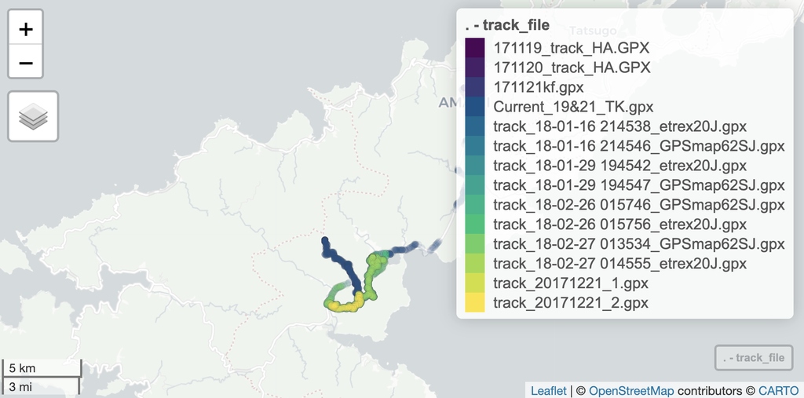

```r
gpx_dt_sub %>%
  filter(road == "三太郎西") %>%
  mapview(zcol = "track_file", alpha.region = 0.1, lwd = 0.1, alpha = 0.2, cex = 3)
```

Now we can make the lines for the roads based on the points. Since 三太郎 road has been analyzed, here we exclude them, and only 4 roads reamains.

[figure not shown]

[figure not shown]

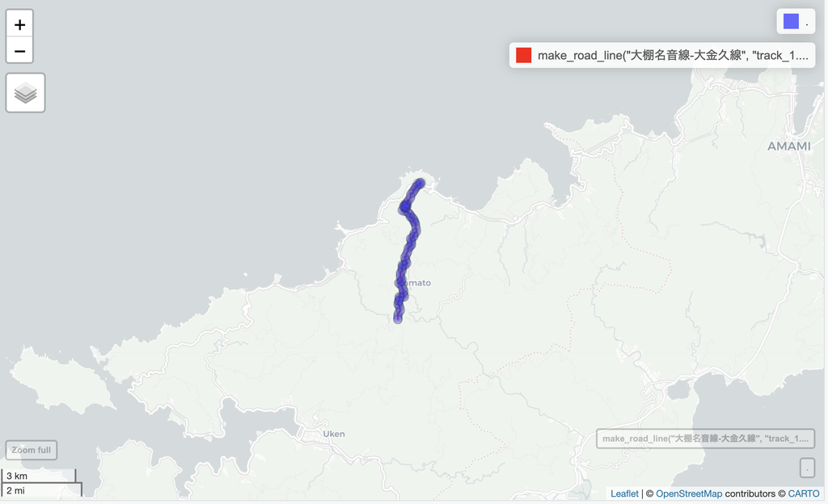

[figure not shown]

```r
gpx_dt_sub %>%
  filter(road == "マテリア線") %>%
  mapview(alpha.region = 0.01, lwd = 0.1, alpha = 0.5, cex = 5) +
  mapview(
    make_road_line(
      "マテリア線", "track_18-01-23 221556_GPSmap62SJ.gpx", 1, "top"
    ),
    color = "red"
  )
gpx_dt_sub %>%
  filter(road == "大名線") %>%
  mapview(alpha.region = 0.01, lwd = 0.1, alpha = 0.2, cex = 5) +
  mapview(
    make_road_line(
      "大名線", "track_18-02-12 205150_GPSmap62SJ.gpx", 1, "top"
    ),
    color = "red"
  )
gpx_dt_sub %>%
  filter(road == "大棚名音線-大金久線") %>%
  mapview(alpha.region = 0.01, lwd = 0.1, alpha = 0.2, cex = 5) +
  mapview(
    make_road_line(
      "大棚名音線-大金久線","track_18-01-10 091522 PM_GPSmap62SJ.gpx", 1, "top"
    ),
    color = "red"
  )
gpx_dt_sub %>%
  filter(road == "スタルマタ") %>%
  mapview(alpha.region = 0.01, lwd = 0.1, alpha = 0.2, cex = 5) +
  mapview(
    make_road_line(
      "スタルマタ", "171120_track_HA.GPX", 0.5, "top"
    ),
    color = "red"
  ) %>% print()
```

Make 100-meter buffer zones based on the road lines:

```r
do.call(rbind, other_road_buff) %>%
  mapview()
```

[interactive chart not shown]

Then for each road buffer zone, I kept the Agoop log points inside the buffer zone, and calculated the number of logs (one dailyid, one color) and unique dailyid (basically the number of cars) per day.

The order of the roads:

```r
tar_file_road
```

```
## # A tibble: 4 × 6
##   road                track_file                              num_point max_num  prop from
##   <chr>               <chr>                                       <int>   <int> <dbl> <chr>
## 1 スタルマタ          171120_track_HA.GPX                           577     577   0.5 top
## 2 マテリア線          track_18-01-23 221556_GPSmap62SJ.gpx          138     138   1   top
## 3 大名線              track_18-02-12 205150_GPSmap62SJ.gpx          270     270   1   top
## 4 大棚名音線-大金久線 track_18-01-10 091522 PM_GPSmap62SJ.gpx       290     290   1   top
```

The number of logs:

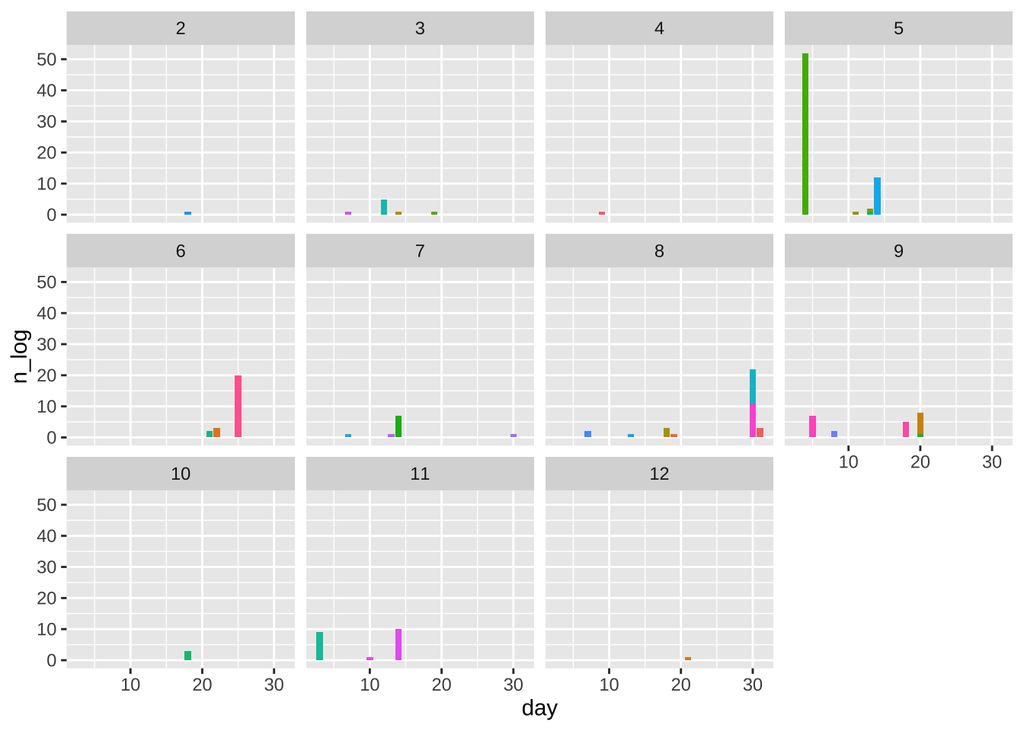

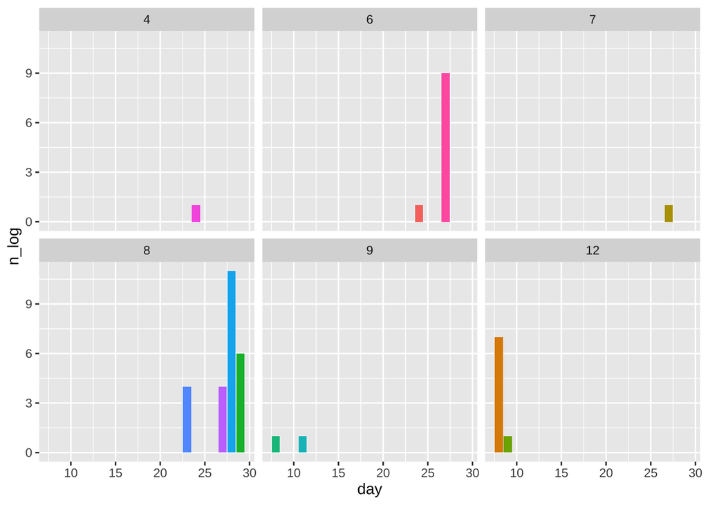

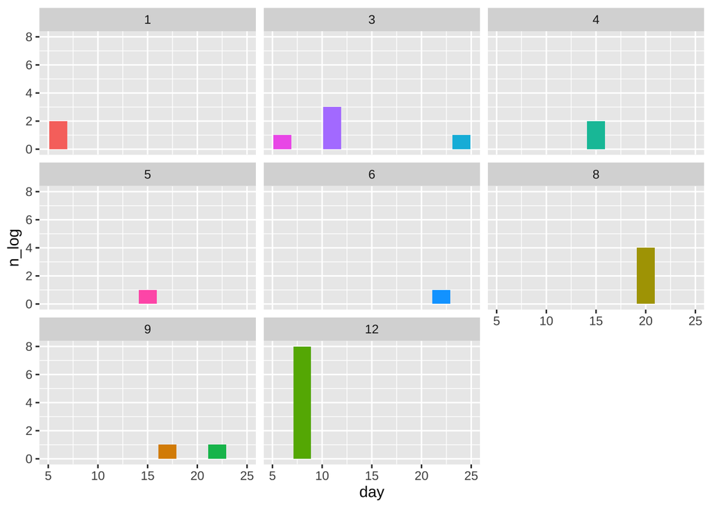

```r
res_nlog
```

The number of dailyids:

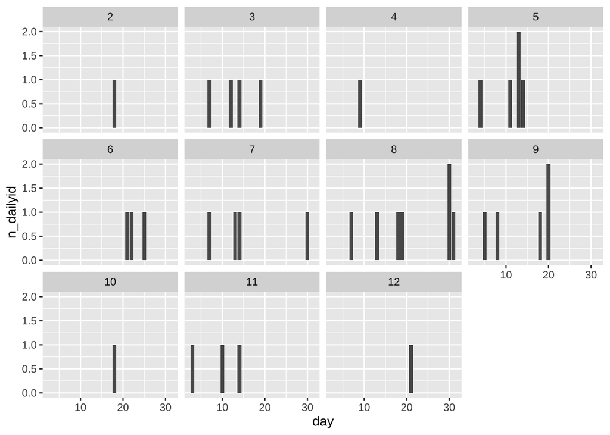

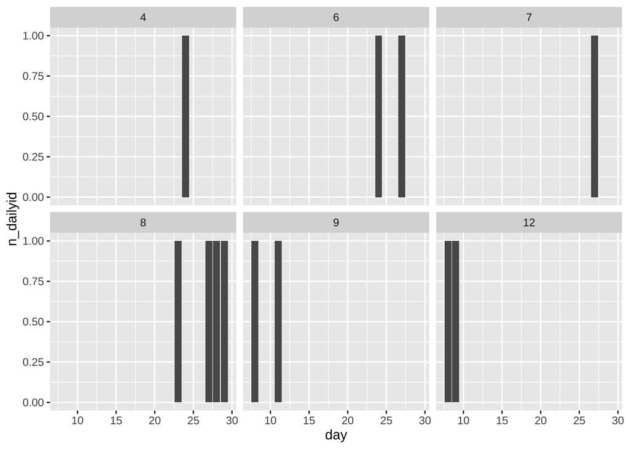

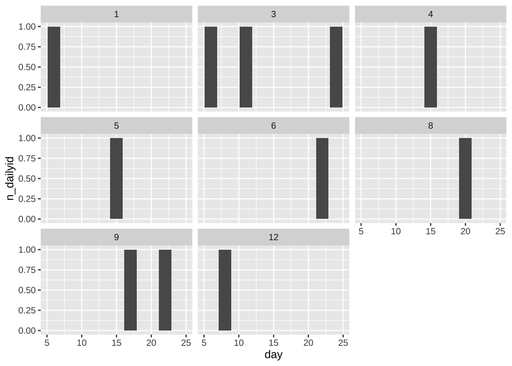

```r
res_ndailyid
```

Then maybe we wonder: what if we expand the buffer zone? So, that is the numebr of dailyid when buffer zone is expand to 200 meters.

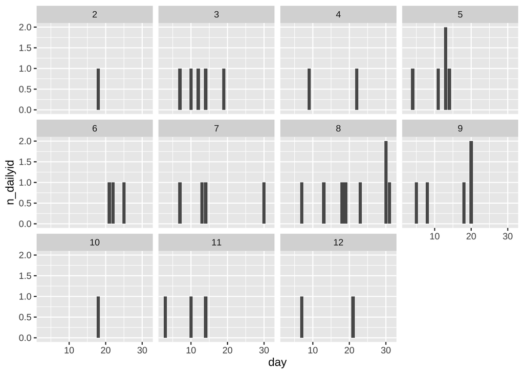

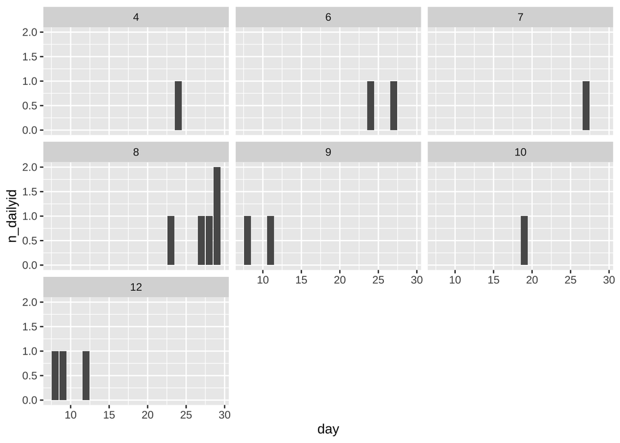

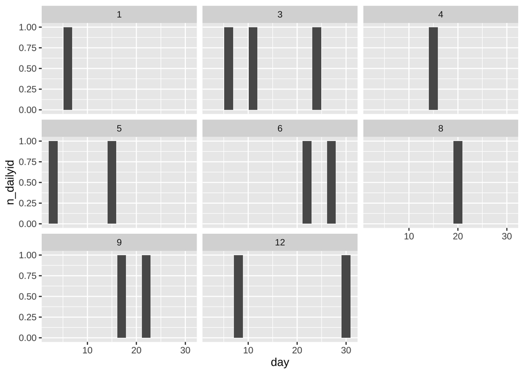

```r
res_ndailyid_200
```